# Vole Skull Analysis

Casey Bray

9/17/2021

```r
knitr::opts_chunk$set(echo = FALSE)
setwd("C:/Users/casey/OneDrive/Desktop/Casey/Dakota State University/DSU Classes/STAT 601/ST-601/Proj 1")

# install.packages("readxl")
# install.packages("ggplot2")
# install.packages("patchwork")
# install.packages("caret")
# install.packages("ggcorrplot")


library("readxl") ## To read in excel file one sheet at a time.
library("ggplot2") ## For histogram, scatter and box plots.
library("patchwork") ## To print multiple plots in a single row/column.
library("caret") ## For cross-validation.
library("ggcorrplot") ## For correlation matrix
```

```r
# Function to preprocess data.
preProcess <- function(x) {
  colnames(x) <- col_names # Subset Dataframe with simple column names
    x <- x[,-1] # Remove Index from Dataframe
      x$ID <- factor(x$ID) # Convert ID to factor for plotting/model
        x <- na.omit(x) # Omit any NA values within Dataframe
  return(x) # Return processed Dataframe
}

## Empty rows, Unknown/22,

# Function to convert any outliers outside IQR to median values.
impute <- function(x){
   qntile1 <- quantile(x, .25) # Calculate 1rst quantile of column
   qntile2 <- quantile(x, .75) # Calculate 3rd quantile of column

   limit <- IQR(x, na.rm = T) # Calculate interquantile range.
   x[x < (qntile1 - (limit * 1.5))] <- median(x) # Below lower limit to median.
   x[x > (qntile2 + (limit * 1.5))] <- median(x) # Above upper limit to median.
   return(x) # Return processed column
}
```

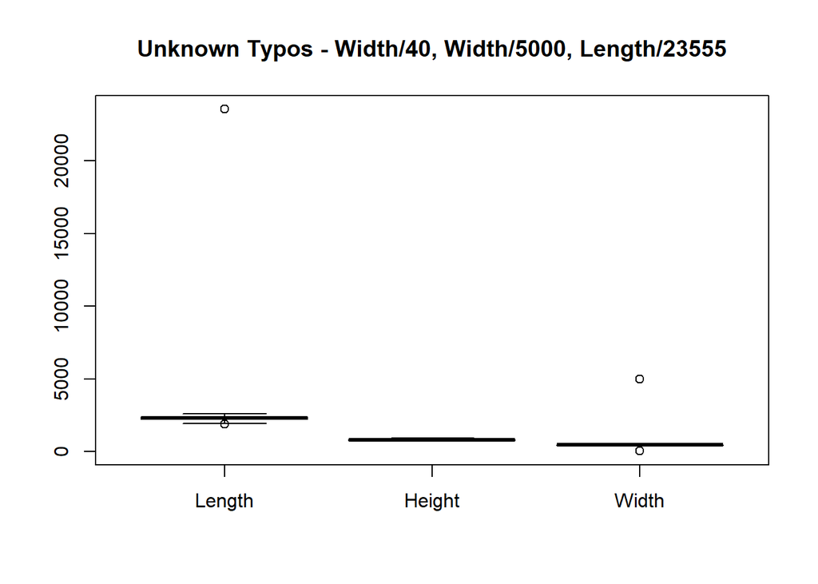

```r
## Setup Column Names for combine.
col_names <- c("Index","ID","Length","Height","Width")

## Read each individual sheet in as dataframe, change column names,
## remove index column, remove any NA values.
unknown <- preProcess(as.data.frame(read_excel("Vole Skulls.xlsm", sheet = 1)))
subterraneus <- preProcess(as.data.frame(read_excel("Vole Skulls.xlsm", sheet = 2)))
multiplex <- preProcess(as.data.frame(read_excel("Vole Skulls.xlsm", sheet = 3)))

## Vizualize typos
boxplot(unknown[,-1],
        main = "Unknown Typos - Width/40, Width/5000, Length/23555")
```

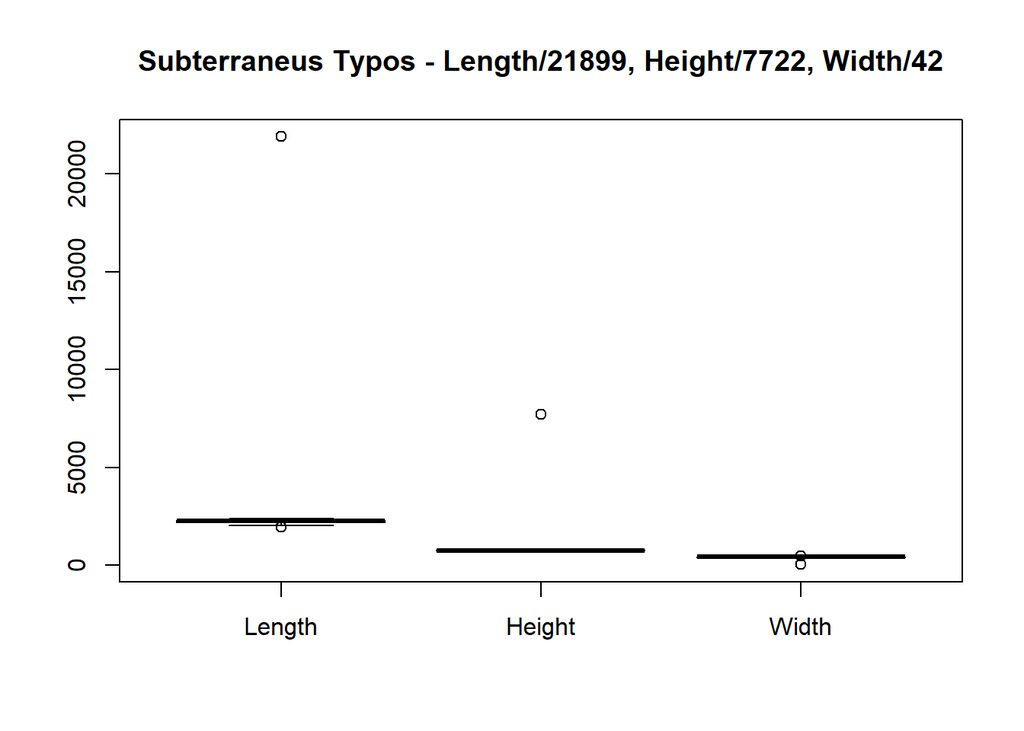

```r
boxplot(subterraneus[,-1],
        main = "Subterraneus Typos - Length/21899, Height/7722, Width/42")
```

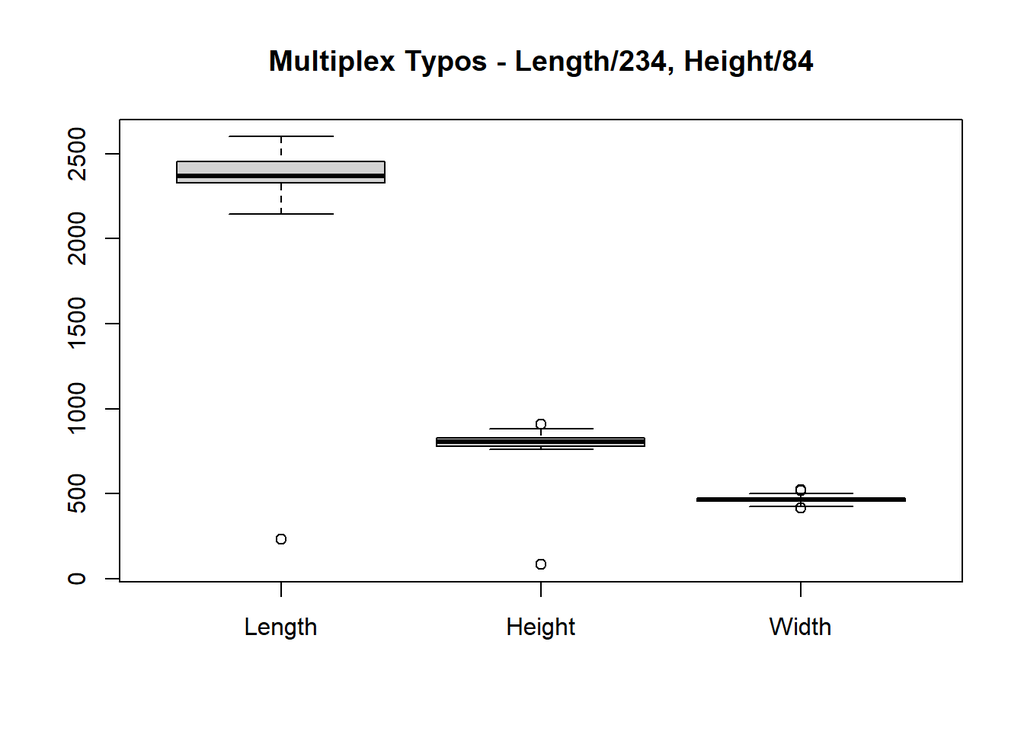

```r
boxplot(multiplex[,-1],
        main = "Multiplex Typos - Length/234, Height/84")
```

```r
## Impute unknown typos - Width/40, Width/5000, Length/23555
unknown$Length[unknown$Length >= 5000] <- median(unknown$Length)
unknown$Width[unknown$Width >= 1000 | unknown$Width <= 200]<-median(unknown$Width)

unknown[,2:4] <- lapply(unknown[,2:4],impute)

## Impute Subterraneus typos - Length/21899, Height/7722, Width/42
subterraneus$Length[subterraneus$Length >= 5000] <- median(subterraneus$Length)
subterraneus$Width[subterraneus$Width <= 300] <- median(subterraneus$Width)
subterraneus$Height[subterraneus$Height >= 5000] <- median(subterraneus$Height)

## Apply impute function for remaining outliers
subterraneus[,2:4] <- lapply(subterraneus[,2:4],impute)

## Impute multiplex typos - Length/234, Height/84
multiplex$Length[multiplex$Length <= 1000] <- median(multiplex$Length)
multiplex$Height[multiplex$Height <= 300] <- median(multiplex$Height)

multiplex[,2:4] <- lapply(multiplex[,2:4],impute)

## Bind multiplex and subterraneus together to form training set.
train <- rbind(subterraneus,multiplex)
```

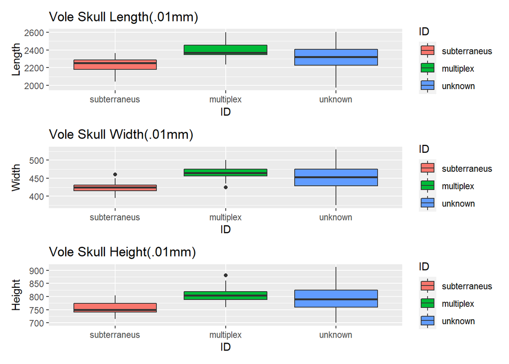

```r
## Bind training set with unknown for visualization.
plot <- rbind(train,unknown)

## Boxplots of ID vs Numerical variables, colored by ID
## Outlier points fall within range due to Interquartile Rule.
## Also, adds varation on data to improve model performance.
b1 <- ggplot(plot, aes(x= ID, y=Length, fill=ID)) +
  geom_boxplot() +
  ggtitle("Vole Skull Length(.01mm)")

b2 <- ggplot(plot, aes(x= ID, y=Width, fill=ID)) +
  geom_boxplot() +
  ggtitle("Vole Skull Width(.01mm)")

b3 <- ggplot(plot, aes(x= ID, y=Height, fill=ID)) +
  geom_boxplot() +
  ggtitle("Vole Skull Height(.01mm)")

b1 + b2 + b3 + plot_layout(ncol = 1)
```

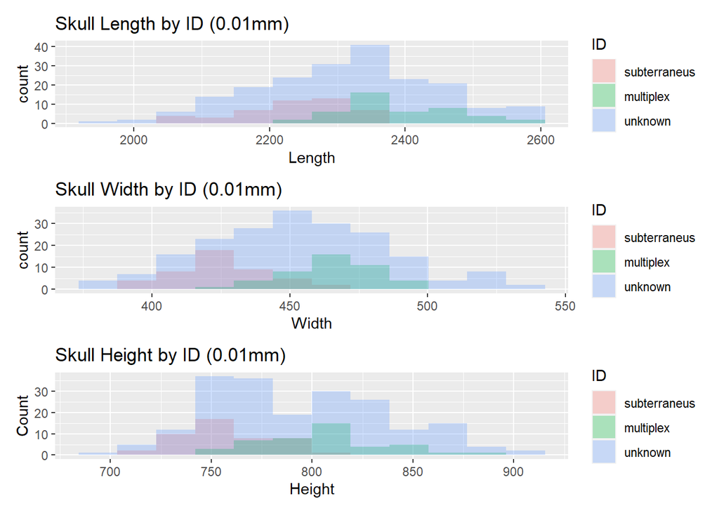

```r
## Histograms of each numeric variables, grouped by ID
h1 <- ggplot(plot, aes(x = Length, fill = ID)) +
  geom_histogram(position = "identity", alpha = 0.3, bins = 12) +
  ggtitle("Skull Length by ID (0.01mm)")

h2 <- ggplot(plot, aes(x = Width, fill = ID)) +
  geom_histogram(position = "identity", alpha = 0.3, bins = 12) +
  ggtitle("Skull Width by ID (0.01mm)")

h3 <- ggplot(plot, aes(x = Height, fill = ID)) +
  geom_histogram(position = "identity", alpha = 0.3, bins = 12) +
  ggtitle("Skull Height by ID (0.01mm)") +
  ylab("Count")

h1 + h2 + h3 + plot_layout(ncol = 1)
```

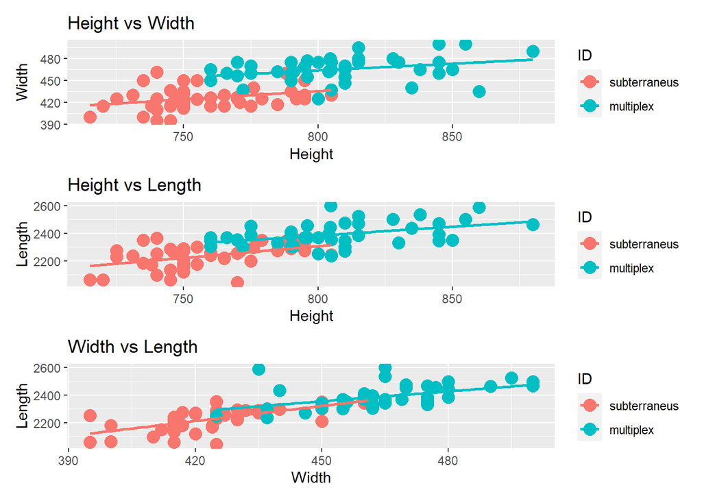

```r
## scatterplots of numeric variables with regression line, colored by ID.
s1 <- ggplot(train, aes(Height, Width, colour = ID)) +
  geom_point(size = 4) +
  geom_smooth(method = "glm", formula = y ~ x, se = FALSE) +
  ggtitle("Height vs Width")

s2 <- ggplot(train, aes(Height, Length, colour = ID)) +
  geom_point(size=4) +
  geom_smooth(method = "glm", formula = y ~ x, se = FALSE) +
  ggtitle("Height vs Length")

s3 <- ggplot(train, aes(Width, Length, colour = ID)) +
  geom_point(size=4) +
  geom_smooth(method = "glm", formula = y ~ x,  se = FALSE)+
  ggtitle("Width vs Length")


s1 + s2 + s3 + plot_layout(ncol = 1)
```

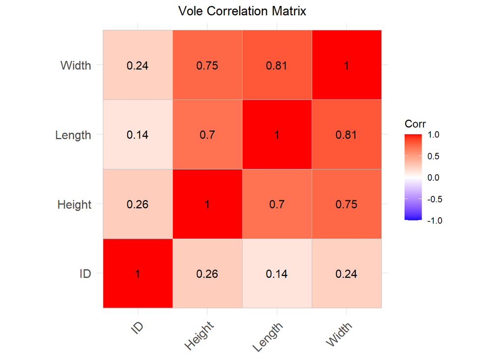

```r
## Display Correlations between columns in data.

plot$ID <- as.numeric(plot$ID)
corr <- cor(plot)
ggcorrplot(corr, hc.order = TRUE, lab = TRUE) +
  ggtitle("Vole Correlation Matrix") +
  theme(plot.title = element_text(hjust = 0.5)) # Adjust title to center
```

```r
table(train$ID)
```

```
##
## subterraneus    multiplex
##           46           44
```

**Exploratory Analysis** Plots agree with statements in background. Subterraneus is smaller than multiplex in all measurements. Unknown shows a range of data that extends on either side of both classes. Predictions of both classes can be expected. Scatterplots show a high correlation and processed data follows Regression line closely. Skull length data appears slightly left skewed in histograms. This may make it difficult to distinguish between subterraneus and multiplex. In boxplots, unknown data seems more dispersed around the multiplex data for all three predictors so I expect more predictions in multiplex. Correlation Matrix shows high correlations between all predictor variables. This could mean multicollinearity, however, I left all data in to add more prediction power to model.

```r
# Provide seed for reproducing.
set.seed(123)

## Setup Cross Validation and save predictions from model.
trctrl <- trainControl(method = "cv", number = 10, savePredictions = TRUE)

## Run model with Response of ID and predictors Length, Width, and Height.
model <- train(ID~., data = train, method = "glm", trControl = trctrl, tuneLength = 0)

## Print model summary with p-values.
summary(model)
```

```
##
## Call:
## NULL
##
## Deviance Residuals:
##      Min        1Q    Median        3Q       Max
## -2.24952  -0.18876  -0.01115   0.18108   1.89162
##
## Coefficients:
##               Estimate Std. Error z value Pr(>|z|)
## (Intercept) -1.094e+02  2.683e+01  -4.075 4.59e-05 ***
## Length       2.520e-03  9.649e-03   0.261  0.79397
## Height       5.888e-02  2.146e-02   2.743  0.00609 **
## Width        1.294e-01  4.416e-02   2.930  0.00339 **
## ---
## Signif. codes:  0 '***' 0.001 '**' 0.01 '*' 0.05 '.' 0.1 ' ' 1
##
## (Dispersion parameter for binomial family taken to be 1)
##
##     Null deviance: 124.72  on 89  degrees of freedom
## Residual deviance:  35.37  on 86  degrees of freedom
## AIC: 43.37
##
## Number of Fisher Scoring iterations: 7
```

```r
## Print model accuracy and kappa values.
model
```

```
## Generalized Linear Model
##
## 90 samples
##  3 predictor
##  2 classes: 'subterraneus', 'multiplex'
##
## No pre-processing
## Resampling: Cross-Validated (10 fold)
## Summary of sample sizes: 80, 80, 82, 82, 82, 81, ...
## Resampling results:
##
##   Accuracy   Kappa
##   0.9138889  0.8280488
```

```r
## Make predictions from model using unclassified data and print summary of
## classifications.
predictions <- predict(model, newdata = unknown)
summary(predictions)
```

```
## subterraneus    multiplex
##           82          117
```

```r
## Create new dataframe of unknown and attach predictions to ID column
results <- unknown
results$ID <- predictions

## Print results with new ID
head(results)
```

|  | ID | Length | Height | Width |
| --- | --- | --- | --- | --- |
| 1 | multiplex | 2232 | 821 | 430 |
| 2 | subterraneus | 2140 | 755 | 405 |
| 3 | subterraneus | 2295 | 767 | 425 |
| 4 | multiplex | 2355 | 842 | 490 |
| 5 | multiplex | 2335 | 814 | 481 |
| 6 | multiplex | 2355 | 815 | 460 |

**Model/Prediction Summary** Model includes simple interactions(ID ~ Length + Width + Height). 10-Fold Cross Validation yields an accuracy of 91% and a Kappa of 83%. The Kappa is very strong at 83% and suggests prediction by chance is relatively low. With an error rate of 9%, the model is highly accurate. Predictions are 82 for subterraneus and 117 for multiplex. Multiplex has 35 more predictions than subterraneus even though the factor ratio was extremely close to 1:1, this supports my findings in the boxplots.